Skip to contents

# 🎓 教程：东北太平洋（FAO 67区）从零到报告

Source: [`vignettes/articles/zh/tutorial-67.Rmd`](https://github.com/Linbojun99/faofishingreport/blob/main/vignettes/articles/zh/tutorial-67.Rmd)

```r
fao_settings(lang = "zh")   # 本文所有图表使用中文
```

📦 **数据来源**：[FAO全球捕捞产量](https://www.fao.org/fishery/collection/capture/en)（Global Capture Production）**2026.1.0**版（FAO于2026-03-30发布，1950–2024年），下载地址Capture_2026.1.0.zip，许可证[CC BY 4.0](https://creativecommons.org/licenses/by/4.0/)。用`fao_data_info()`查看你使用的版本和引用格式。

本教程以**东北太平洋（FAO 67区）**为例，完整演示一个FAO主要渔区的评估：从一个空白的R会话开始，直到写出一份完整的报告。67区从白令海东部和阿拉斯加湾起，沿加拿大和美国的海岸向南延伸到加利福尼亚北部（北纬40°）。本教程按你自己工作时的顺序，用到了本包的几乎每一个函数，并说明**每张图显示什么、怎么看，以及它说明了该渔区的什么情况**。如果你从未用过本包，请从头到尾阅读，边读边运行代码；如果你已经熟悉本包，可以用目录直接跳到需要的步骤。

67区是很好的教学例子，因为它的历史清楚地写在数据里：有二十年时间，日本和苏联的船队捕走了该渔区很大一部分渔获，直到1977年美国和加拿大把渔业管辖范围扩大到200海里，渔获才转到它们自己的船队手中。这里一个物种（狭鳕）占主导地位，有一个著名的过度捕捞案例（Pacific ocean perch，一种平鲉属岩鱼），还有北太平洋的鲑鱼渔业；它的数据也是所有FAO渔区中最好的之一。下文中的每个数字都是在生成本页时由数据算出的，因此与图表一致。

| 步骤 | 做什么 | 函数 |
| --- | --- | --- |
| 1 | 准备R、项目文件夹和设置 | `fao_settings()`、`fao_font()` |
| 2 | 获取FAO数据，了解其版本，保存自己的副本 | `check_fao_update()`、`download_fao_data()`、`load_fao_data()`、`fao_data_info()` |
| 3 | 渔区的渔获量：趋势、阶段、占全球的比例 | `fishing_area_data()` |
| 4 | 主要物种 | `fishing_area_species()` |
| 5 | 主要国家 | `fishing_area_country()` |
| 6 | 一个物种，一个国家 | `species_country()`、`country_species()`、`country_analysis()` |
| 7 | 类群结构、资源状态、趋势与突变 | `species_group_composition()`、`stock_status()`、`peak_trend()`、`regime_shift()`、`area_overview()` |
| 8 | 数据质量、多样性与船队 | `data_quality()`、`diversity_concentration()`、`country_group_summary()`、`coastal_distant()` |
| 9 | 文献中的方法 | `catch_shocks()`、`collapse_analysis()`、`catch_synchrony()`、`pelagic_demersal()`、`distant_water_profile()` |
| 10 | 物种特征与温度 | `fishbase_match()`、`fao_area_sst()`、`mean_temperature_catch()` |
| 11 | 主要物种的资源评估 | `cmsy_setup()`、`cmsy_area()` |
| 12 | Word、LaTeX和PDF格式的报告（用TinyTeX生成PDF） | `fao_report()`、`tinytex::install_tinytex()` |
| 13 | 所有文件保存在哪里，以及如何重新读取 |  |

**图表的解读方式。**每张图下方，“🔎 怎么看这张图”说明坐标轴、颜色和线条的含义，“67区的结果”给出该渔区的结果。图表描述的是**报告的渔获量**：它们说明的是上岸并上报给FAO的渔获量，而不是海里有多少鱼。得出每一个结论时都要记住这一点。

## 1. 🧰 准备工作

安装一次本包，同时安装它用到的所有包（详见🚀 快速入门），然后在每次会话开始时加载它：

```r
install.packages("remotes")
remotes::install_github("Linbojun99/faofishingreport", dependencies = TRUE)
```

```r
library(faofishingreport)
```

**在项目文件夹中工作。**每个函数都把图表和表格保存在*工作目录*（`getwd()`返回的文件夹）中。每项评估建一个文件夹，例如建一个RStudio项目，或者自己设置：

```r
dir.create("~/fao67", showWarnings = FALSE)
setwd("~/fao67")
getwd()
```

**为本次会话一次性选好设置**：用`fao_settings()`设置图表的语言、风格和输出格式。不带参数调用它，可以查看当前的设置。

```r
fao_settings(lang = "zh", theme = "classic", dpi = 100, pptx = FALSE)
```

| 设置 | 本文取值 | 作用 |
| --- | --- | --- |
| `lang` | `"zh"` | 图表文字和名称使用中文；`"en"`为英文，`"both"`为中英双语 |
| `theme` | `"classic"` | 图表风格（见🎨 自定义图表与地图） |
| `dpi` | `100` | PNG文件的分辨率（印刷用300） |
| `pptx` | `FALSE` | `TRUE`时把每张图同时保存为可编辑的PowerPoint文件 |

图表字体会按你的操作系统选择（`fao_font()`显示所用的字体）：Windows上为SimSun，macOS上为Songti SC，Linux上为Noto Serif CJK SC，以保证中文名称能正常显示。

## 2. 💾 获取数据

### 2.1 检查FAO的最新版本

FAO每年发布一次全球捕捞产量（Global Capture Production）统计。本包自带一个较新的版本；`check_fao_update()`把它与网上的最新版本比较，`download_fao_data()`下载并转换一个版本（约6 MB，通常不到一分钟）：

```r
check_fao_update()     # 比较网上的最新版本与你电脑上的数据
download_fao_data()    # 下载最新版本（只有FAO发布了新版本时才需要）
```

### 2.2 加载数据，并确认所用的版本

`load_fao_data()`返回你电脑上可用的最新版本（下载过的版本，否则为本包自带的版本），每个国家、物种条目、渔区和年份一行：

```r
fao <- load_fao_data()
dim(fao)
```

```
#> [1] 1024698       8
```

```r
show_table(fao[fao$FAO.major.fishing.area..Name. == "Pacific, Northeast" & fao$Year == 2024, ], n = 5)
```

|  | Country..Name. | ASFIS.species..Name. | FAO.major.fishing.area..Name. | Unit..Name. | Unit | Year | Production | Production.Type |
| --- | --- | --- | --- | --- | --- | --- | --- | --- |
| 95717 | Canada | Pink(=Humpback) salmon | Pacific, Northeast | Tonnes - live weight | TLW, Number | 2024 | 3,659.42 | actual |
| 95792 | Canada | Chum(=Keta=Dog) salmon | Pacific, Northeast | Tonnes - live weight | TLW, Number | 2024 | 1,840.59 | actual |
| 95867 | Canada | Coho(=Silver) salmon | Pacific, Northeast | Tonnes - live weight | TLW, Number | 2024 | 432.38 | actual |
| 95908 | Canada | Rainbow trout | Pacific, Northeast | Tonnes - live weight | TLW, Number | 2024 | 0.00 | actual |
| 95983 | Canada | Sockeye(=Red) salmon | Pacific, Northeast | Tonnes - live weight | TLW, Number | 2024 | 1,418.83 | actual |

| 列 | 含义 |
| --- | --- |
| `Country..Name.` | 上报国家（FAO英文名） |
| `ASFIS.species..Name.` | FAO物种条目（一个种、属、科，或“Marine fishes nei”这样的类群；*nei* = not elsewhere included，即“未另列明”） |
| `FAO.major.fishing.area..Name.` | FAO主要渔区 |
| `Year`、`Production` | 年份和渔获量（吨，活重） |
| `Production.Type` | 数值是怎样得来的：国家上报、FAO估算…… |

**务必记录所用的版本**：FAO每发布一个新版本都会修订以前的年份，所以报告必须说明它依据的是哪个版本。`fao_data_info()`给出版本号、相关日期、下载链接和引用格式：

```r
info <- fao_data_info()
info
```

```
#> FAO Global Capture Production
#>   Release:   2026.1.0 (published by FAO on 2026-03-30)
#>   Years:     1950-2024
#>   File:      https://www.fao.org/fishery/static/Data/Capture_2026.1.0.zip
#>   Obtained:  bundled with faofishingreport, downloaded from FAO on 2026-10-10
#>   Licence:   CC BY 4.0 (https://www.fao.org/contact-us/terms/db-terms-of-use/en)
#>   Citation:  FAO. 2026. Global Capture Production 1950-2024, release 2026.1.0. In: Fisheries and Aquaculture [online]. Rome. [Cited 10 October 2026]. https://www.fao.org/fishery/collection/capture/en. Licence: CC BY 4.0.
```

### 2.3 数据保存在哪里

下载的版本保存在本包的数据文件夹`fao_data_dir()`中，以后每次会话都会再用。要在多台电脑之间或团队内共用一个文件夹，在`~/.Renviron`中设置环境变量`FAOFISHINGREPORT_DATA_DIR`（见💾 FAO数据：下载与自定义）。某个渔区的数据可以像任何R对象一样另存一份副本：

```r
fao_data_dir()
```

```
#> [1] "/home/runner/.local/share/R/faofishingreport"
```

```r
area67_raw <- fao[fao$FAO.major.fishing.area..Name. == "Pacific, Northeast", ]
saveRDS(area67_raw, "area67_data.rds")                 # 在R中读取：readRDS("area67_data.rds")
write.csv(area67_raw, "area67_data.csv", row.names = FALSE, fileEncoding = "UTF-8")   # 用Excel打开
```

## 3. 🌊 渔区的渔获量

`fishing_area_data()`的输入是一个FAO主要渔区的名称，它提取该渔区的数据，绘制总渔获量及其阶段，以及该渔区占全球海洋渔获量的比例：

```r
NEP <- fishing_area_data("Pacific, Northeast")
area67 <- NEP$area_data
```

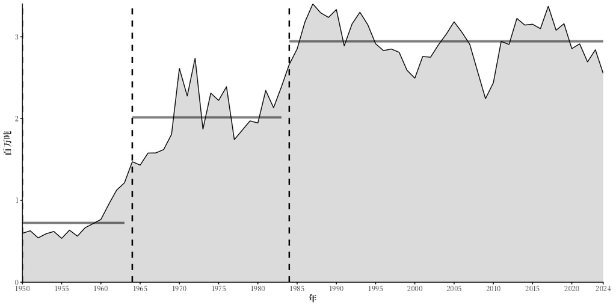

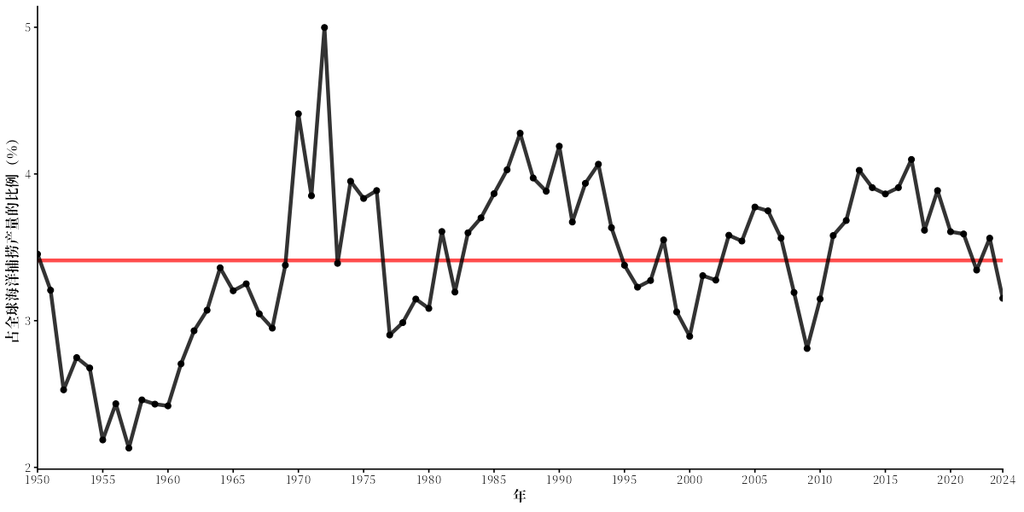

**`fishing_trend.png`：总渔获量及其阶段**

🔎 *怎么看这张图*：灰色面积是该渔区每年的渔获量（百万吨）。竖直虚线是**突变点**，即平均渔获量发生变化的年份，用Bai-Perron检验（`strucchange::breakpoints()`）找出；每条虚线处开始一个新的阶段。灰色水平线段是各阶段的平均渔获量。

*67区的结果*：渔获量从1950年的59.8万t增长到1987年的峰值340.2万t，2024年为255.1万t。检验共找出3个阶段：1950–1963年（平均72.5万t）；1964–1983年（平均201.5万t）；1984–2024年（平均294.4万t）。这些阶段对应船队的历史，后面各步会逐一说明：1950年代加拿大和美国以鲑鱼和鲱鱼为主的少量渔获；1960年代起苏联和日本的拖网船队来到白令海和阿拉斯加湾捕捞底层鱼类；以及1977年200海里渔业管辖区设立之后，美国船队发展壮大，形成了最近四十年较高而平稳的渔获量。

**`fishing_percentage.png`：占全球海洋渔获量的比例**

🔎 *怎么看这张图*：每个点是当年该渔区渔获量占所有FAO海洋渔区渔获量的百分比；红线是这些比例的平均值。内陆水域不计算在内。

*67区的结果*：该渔区占全球海洋渔获量的2.1%至5.0%，平均为3.4%，2024年为3.2%。比例高于其平均值，说明该渔区的增长快于（或下降慢于）世界其他海域：这里是在1980年代，即该渔区的渔获量达到高位平台的时候。

`NEP`是一个列表：`NEP$area_data`（该渔区的数据，后面各步都要用到）、`NEP$coefs_data`（各阶段：起止年份和平均渔获量）和`NEP$act_world_map`（地图数据）。用`saveRDS(NEP, "NEP.rds")`保存，以后可以接着分析而不必重新计算。

## 4. 🐟 主要物种

`fishing_area_species()`按渔获量给物种条目排序（`rank_range = 1:10`：最大的十个），绘制它们的渔获量随时间的变化，并找出每个物种的阶段：

```r
sp <- fishing_area_species(area67, rank_range = 1:10)
```

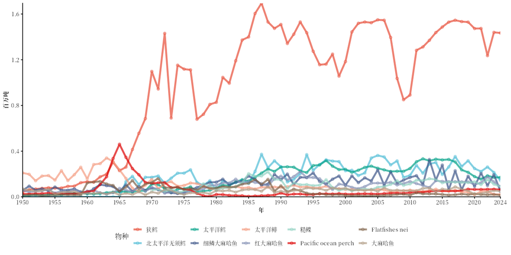

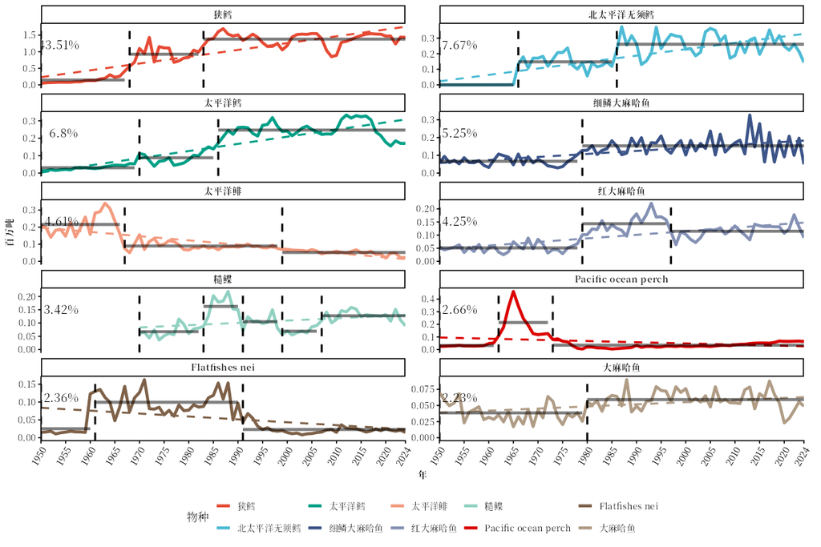

**`area_species.png`：主要物种放在一起**，以及**`area_species_wrap.png`：每个物种一个分面**

🔎 *怎么看这些图*：第一张图把十个物种条目放在同一个纵轴上，以便比较它们的大小。第二张图给每个物种一个单独的分面和纵轴，这样小物种也看得清：折线是每年的渔获量，竖直虚线和灰色线段是该物种的阶段，倾斜的虚线是线性趋势，百分比是该物种在该渔区历年渔获量中所占的比例。

*67区的结果*：最近五年最大的条目是狭鳕（每年141.1万t）、北太平洋无须鳕（每年21.8万t）、太平洋鳕（每年17.2万t）、细鳞大麻哈鱼（每年12.9万t）、红大麻哈鱼（每年12.6万t）。有四个特点很突出：

- **一个物种占主导。**1950年以来，狭鳕占该渔区全部渔获量的43.5%，而其后九个条目合计占39.3%。狭鳕的变化就是该渔区的变化。
- **暴涨暴跌。**Pacific ocean perch（一种平鲉属岩鱼）的渔获量从1950年的2.5万t增长到1965年的峰值46.1万t，主要由苏联和日本的拖网船捕捞，十年后降到6.6万t。岩鱼生长慢、寿命长，承受不了长期的高强度捕捞。
- **逐渐消失的渔业。**太平洋鲱的渔获量1950年为21.0万t，1963年达到峰值34.0万t，2024年只有2.2万t。
- **两年周期。**细鳞大麻哈鱼（pink salmon）的生命周期为两年，因此奇数年和偶数年的洄游群体交替出现：2000年以来，奇数年的渔获量平均为21.3万t，偶数年为10.6万t，这就是它的分面中锯齿状的折线。

改变`rank_range`就会改变显示的物种，例如`rank_range = 11:20`显示其后的十个。只有在`timeseries_analysis = FALSE`时，分面中的折线才会被平滑，同时也不再显示阶段。

FAO物种名录（ASFIS）中没有中文名的物种，本包使用FishBase和SeaLifeBase中给中国大陆的简体中文俗名（如Pacific cod，太平洋鳕）；两者都没有的（如Pacific ocean perch），图表和表格中显示英文名。

## 5. 🌎 主要国家

`fishing_area_country()`对国家做同样的分析，并加上一张各国渔获量的地图：

```r
co <- fishing_area_country(area67, rank_range = 1:8)
```

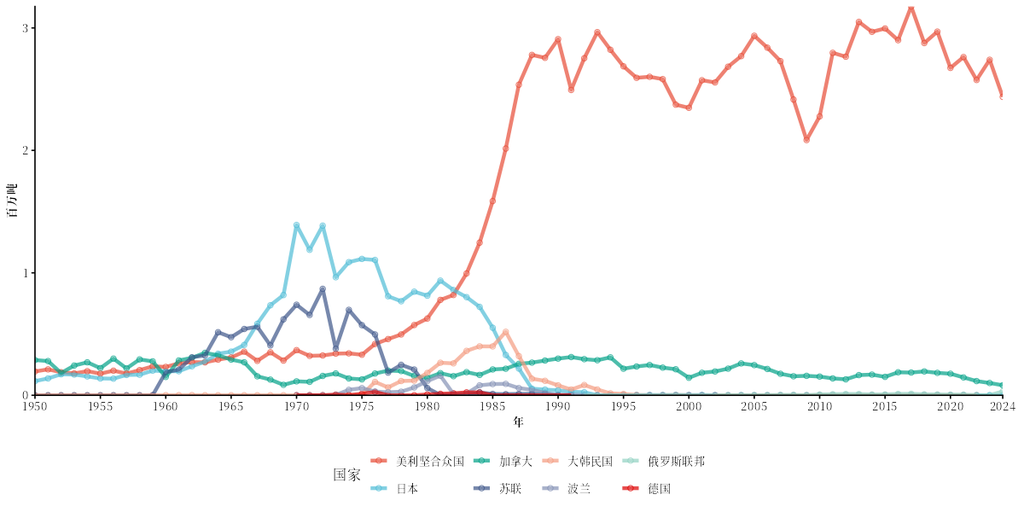

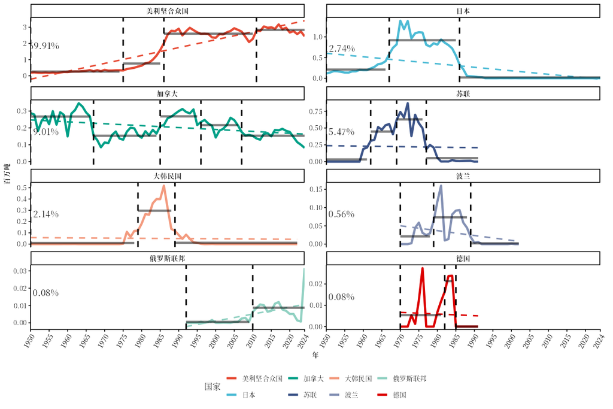

*67区的结果*：最近五年，美利坚合众国（95.2%）和加拿大（4.5%）几乎占了全部渔获量。但过去并非如此。1950年代有9年**加拿大**是渔获量最大的国家；**苏联**在1962–1966年最大（峰值为1972年的86.9万t），**日本**在1967–1982年最大（峰值为1970年的139.1万t）；**大韩民国**在1986年达到51.8万t。**美国**的份额1970年只有14%，1980年为32%，1990年为87%，2024年为96%；从1983年起美国每年的渔获量都超过日本，日本在该渔区最后一次超过1000 t的渔获是在2001年。

这一变化有明确的原因。美国的《渔业养护与管理法》（Fishery Conservation and Management Act，1976年通过，1977年3月1日生效）设立了200海里渔业管辖区，只把美国船队捕不完的那部分渔获分配给外国船队；加拿大也在同一年把渔业管辖范围扩大到200海里。1980年代，美国渔船先是在海上把渔获卖给外国加工船（“合资渔业”，joint ventures），后来改为运回本国上岸，直到外国捕捞结束。日本、苏联、韩国和波兰的分面都在这些年里结束。

## 6. 🔍 一个物种，一个国家

### 6.1 谁在捕捞某个物种：`species_country()`

```r
pollock <- species_country(area67, "Alaska pollock(=Walleye poll.)", rank_range = 1:5)
```

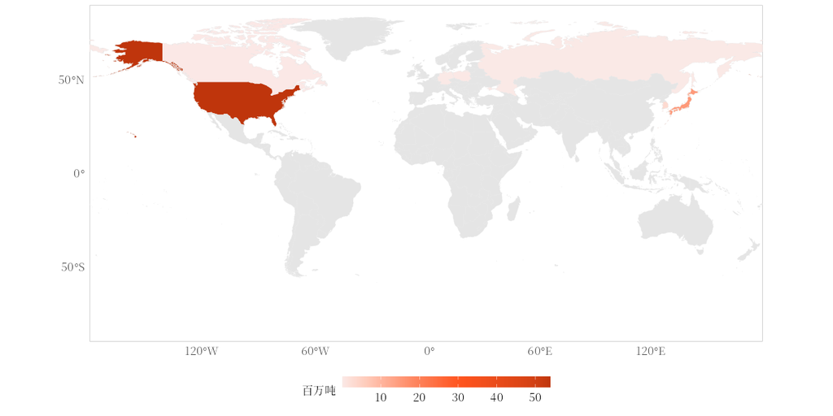

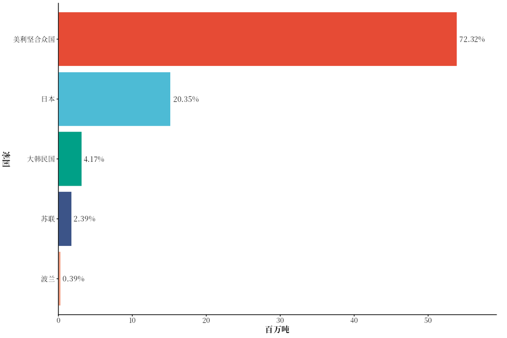

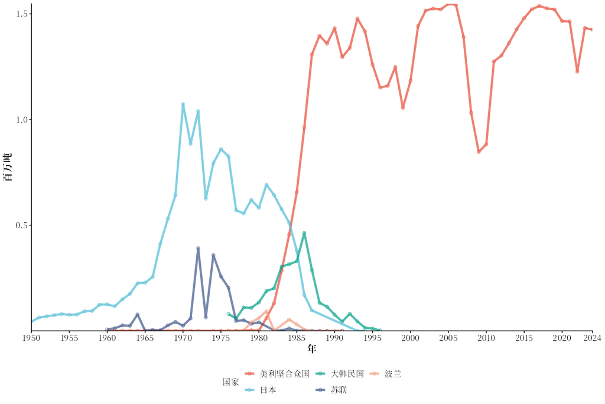

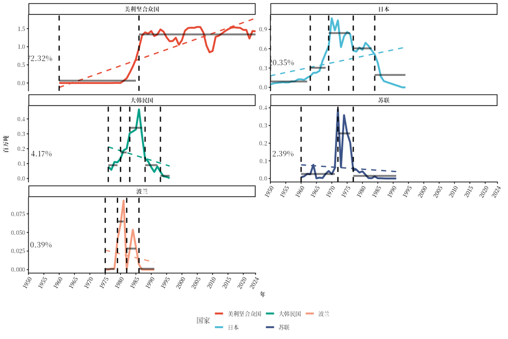

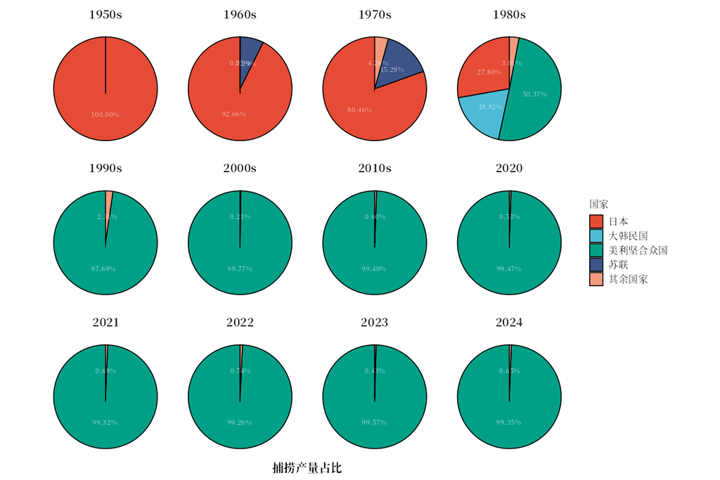

🔎 *怎么看这些图*：这些图把一个物种条目的渔获量按国家分解：排名图和小多图（每个国家一个分面，带阶段）、按时期显示各国占比的饼图，以及一张地图。物种名称必须按FAO数据中的写法给出（`unique(area67$ASFIS.species..Name.)`列出全部名称；`fao_translate()`给出中文名）。

*67区的结果*：狭鳕的历史就是该渔区历史的缩影。日本最先开发了这一渔业（峰值为1970年的107.3万t），随后是苏联（峰值为1972年的39.1万t）和大韩民国（峰值为1986年的46.4万t）。1980年以前美国几乎不捕狭鳕；它的渔获量在1980年代的合资渔业中增长起来，此后一直是唯一的大宗渔获，峰值为2005年的154.7万t。

### 6.2 一个国家捕什么：`country_species()`和`country_analysis()`

`country_species()`把一个国家在该渔区的渔获量按物种分解；`country_analysis()`考察同一个国家在**所有**FAO渔区的渔获量，看它在哪里捕捞：

```r
usa_67 <- country_species(area67, "United States of America", rank_range = 1:10)
usa_all <- country_analysis("United States of America", rank_range = 1:10)
```

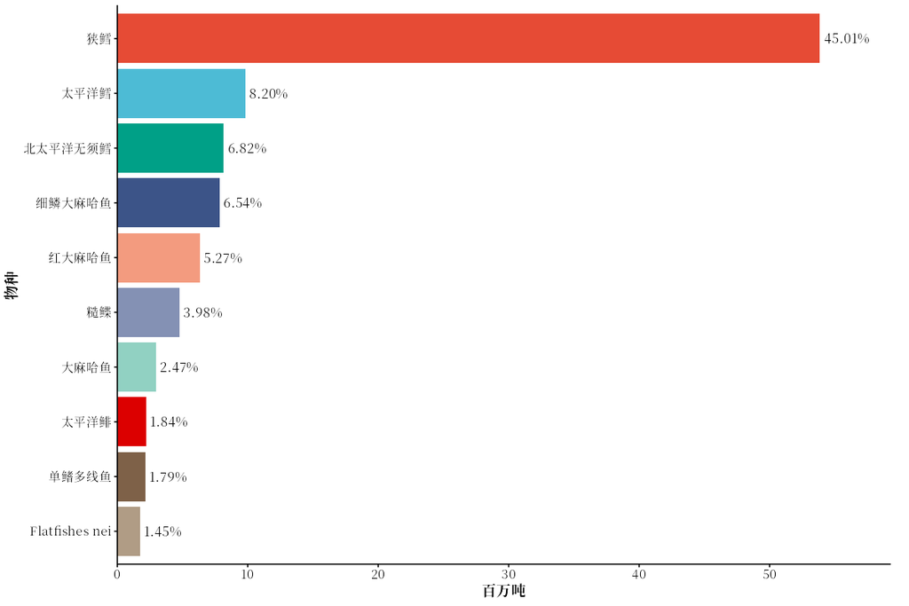

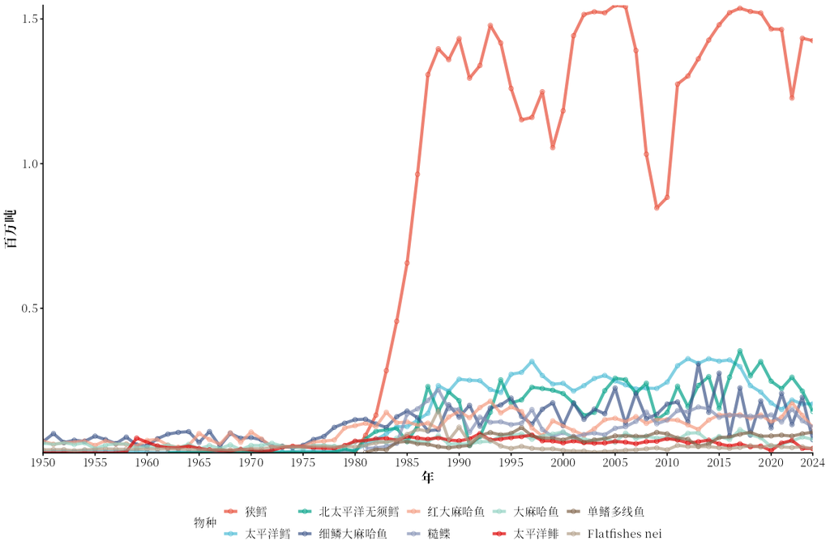

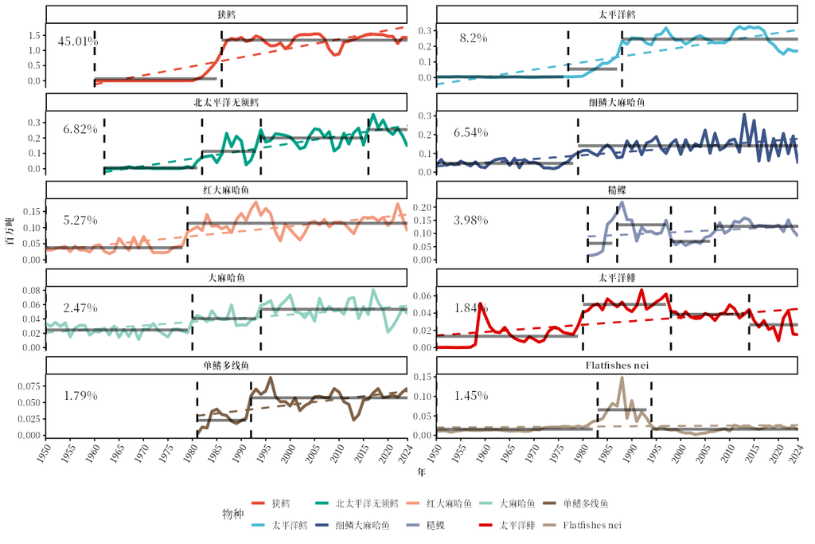

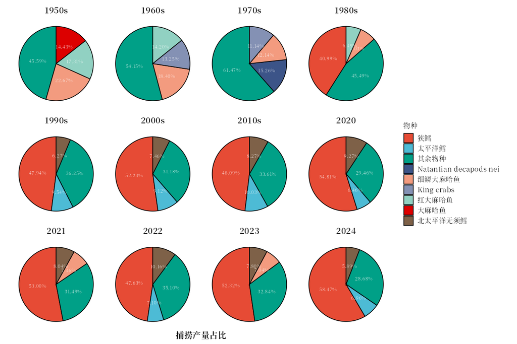

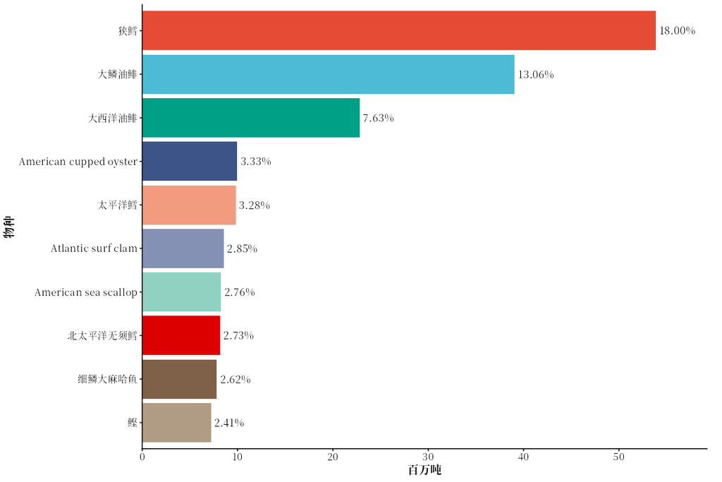

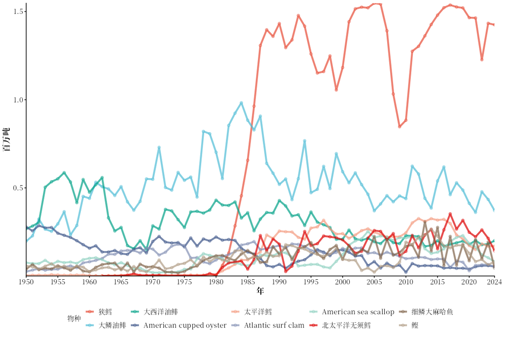

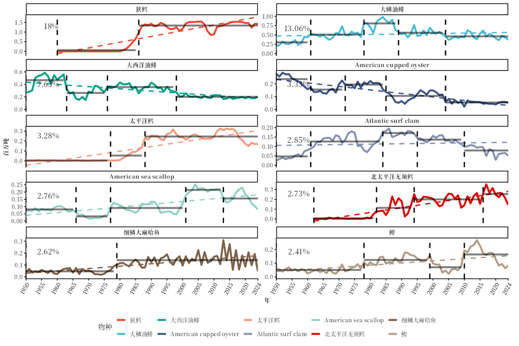

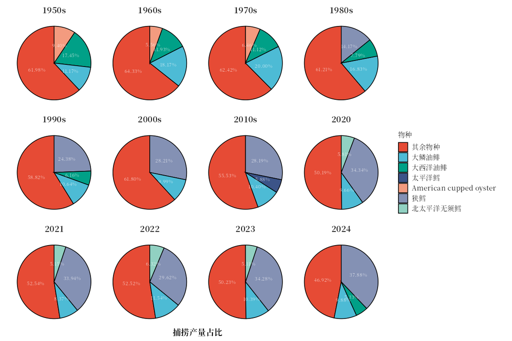

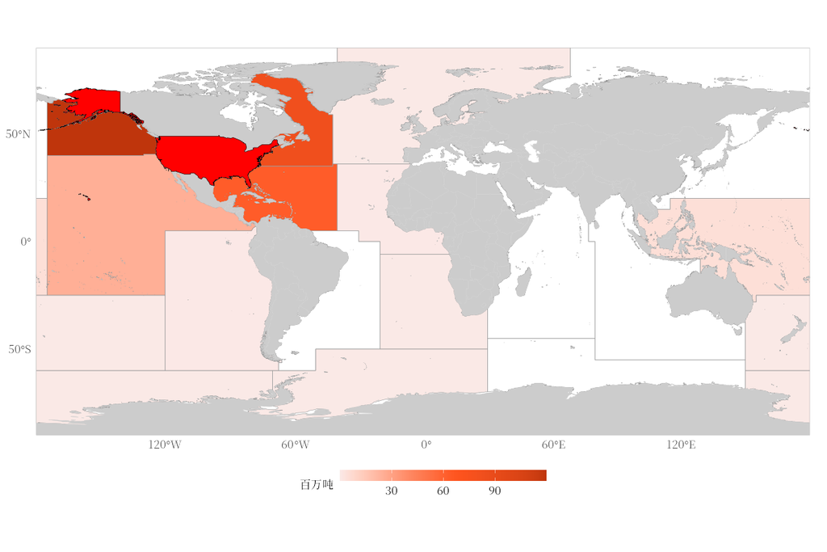

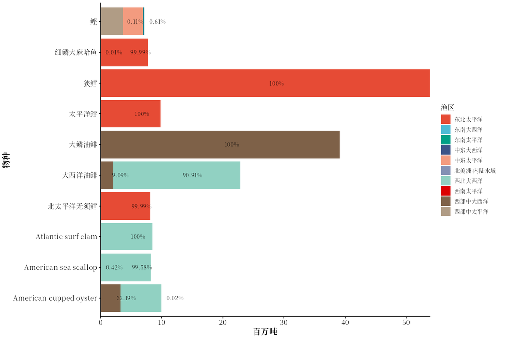

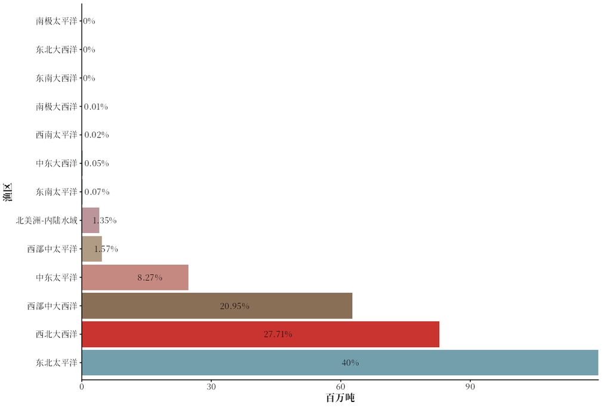

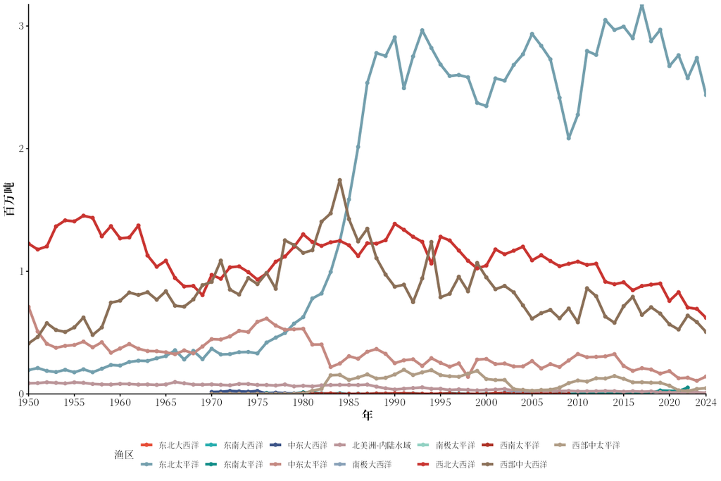

[1 more figures not shown]

🔎 *怎么看这些图*：`United_States_of_America_species_*`图：美国在67区捕捞的物种。`United_States_of_Americaanalysis_*`图：美国在所有渔区捕捞的物种、它在各渔区的渔获量（`United_States_of_Americayearly_area_production.png`，每个渔区一条线），以及它作业渔区的地图。

*结果*：1970年代，美国在67区的渔获主要是Natantian decapods nei、细鳞大麻哈鱼、King crabs，即沿岸渔业的鲑鱼、蟹类和虾类。最近五年则是狭鳕、北太平洋无须鳕、太平洋鳕，也就是过去由外国船队捕捞的底层鱼类。在所有FAO渔区中，67区从1985年超过西北大西洋起，一直是美国最大的渔区，现在它提供的渔获量远远超过其他渔区。

## 7. 📈 类群结构、资源状态、趋势与突变

### 7.1 物种类群：`species_group_composition()`

```r
groups <- species_group_composition(area67)
```

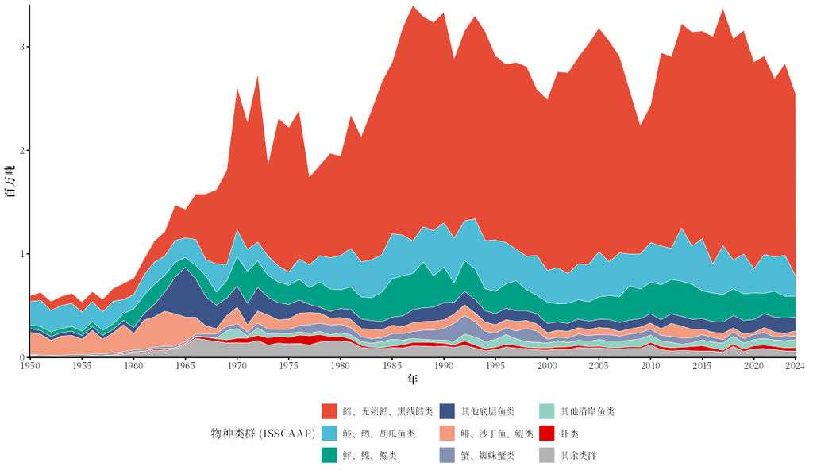

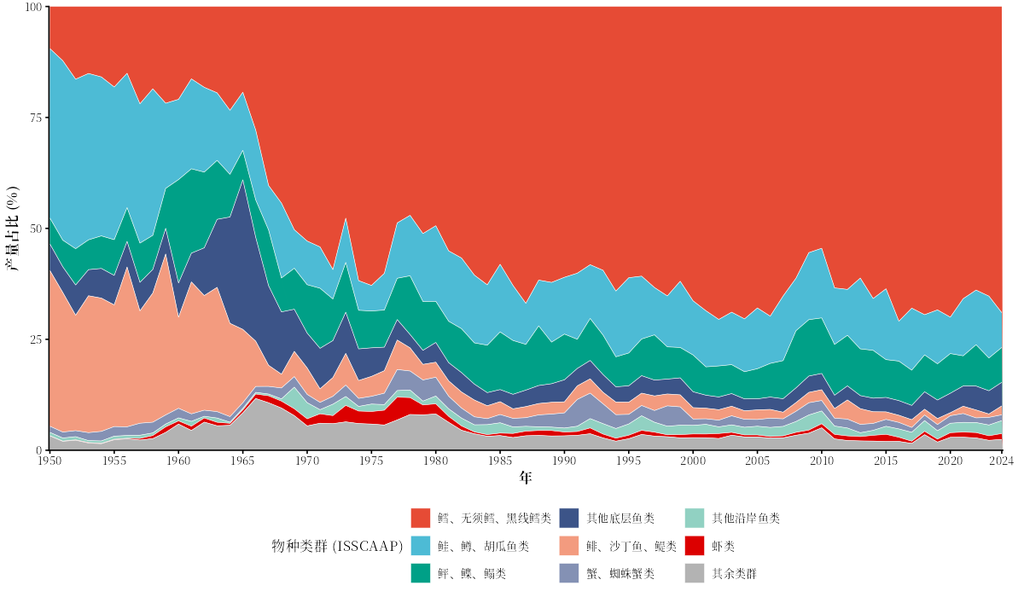

🔎 *怎么看这张图*：物种条目按FAO的ISSCAAP类群归类（如“鲱、沙丁鱼、鳀类”“鳕、无须鳕、黑线鳕类”）。堆积面积图显示每个类群的渔获量，`_share`图显示其占渔获量的百分比；最大的几个类群单独标出名称，其余合并为“其余类群”。

*67区的结果*：1950年，鲑、鳟、胡瓜鱼类（38%）和鲱、沙丁鱼、鳀类（35%）占了大部分渔获量，鳕、无须鳕、黑线鳕类只占9%。拖网渔业在二十年内改变了这一格局：鳕、无须鳕、黑线鳕类（狭鳕、太平洋鳕、北太平洋无须鳕）1970年达到53%，2024年为69%，鲆、鲽、鳎类居第二。

### 7.2 资源状态图：`stock_status()`

```r
status <- stock_status(area67)
```

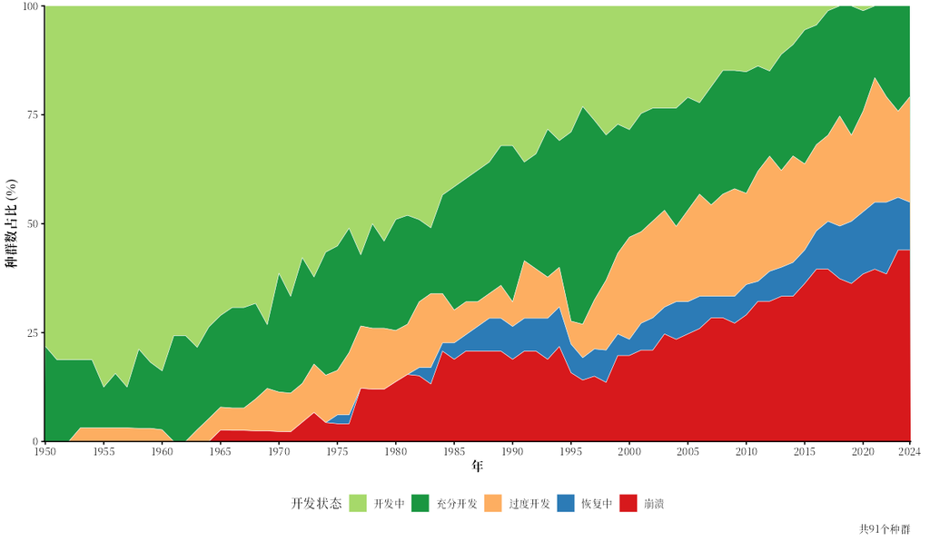

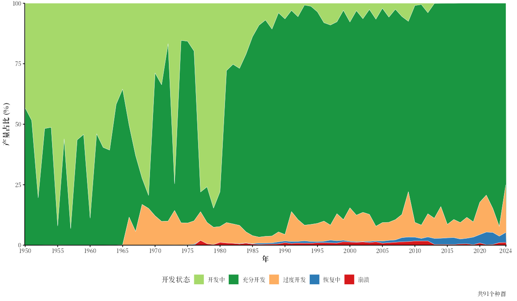

🔎 *怎么看这些图*：每个“种群”是该渔区一个物种条目的渔获量序列。每一年，按种群渔获量相对于其自身峰值的比例划分状态（Kleisner等，2013）：**开发中**（峰值之前，低于峰值的一半）、**充分开发**（高于峰值的一半）、**过度开发**（峰值之后，为峰值的10%–50%）、**崩溃**（峰值之后，低于10%）和**恢复中**（崩溃之后回升到10%–50%）。`_stocks`图统计种群数，`_catch`图按渔获量加权。

*67区的结果*：在91个种群中，按种群数计，2024年有44.0%处于崩溃状态，24.2%处于过度开发状态。按渔获量加权，情况就大不相同了：崩溃种群只占渔获量的1.1%，过度开发种群占19.7%，而仍高于其峰值一半的充分开发种群占75.0%。许多小种群远低于过去的峰值（其中一些，如鲱鱼，是因为渔业关闭或不再有市场需求），但提供大部分渔获量的大种群并非如此。

**不能得出的结论。**资源状态图只使用渔获量。渔获量下降可能是因为鱼变少了，也可能是因为捕捞减少、管理措施、市场或上报方式的变化（例如某个物种改为以“nei”上报）。用它来提出问题，而不要把它当作资源评估；`smooth = TRUE`按3年滑动平均划分状态，可以减小个别异常年份的影响。

### 7.3 各物种的峰值与趋势：`peak_trend()`

```r
pt <- peak_trend(area67)
show_table(pt[, c("name", "peak_year", "pct_of_peak", "growth_pct_per_year", "trend")], n = 11)
```

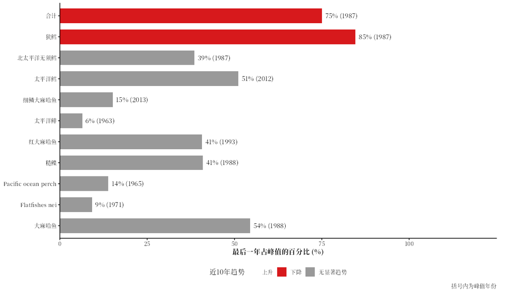

🔎 *怎么看这张图*：对每个主要物种给出：峰值渔获量出现的年份，最后一年的渔获量相当于峰值的百分比，最近十年的年均增长率，以及这一趋势的Mann-Kendall检验（*P* < 0.05时为`"up"`（上升）或`"down"`（下降），否则为`"none"`）。在67区，总渔获量和狭鳕都接近其1980年代末的峰值，而太平洋鲱和Pacific ocean perch远低于各自的峰值。

### 7.4 同步突变：`regime_shift()`

```r
shifts <- regime_shift(area67)
```

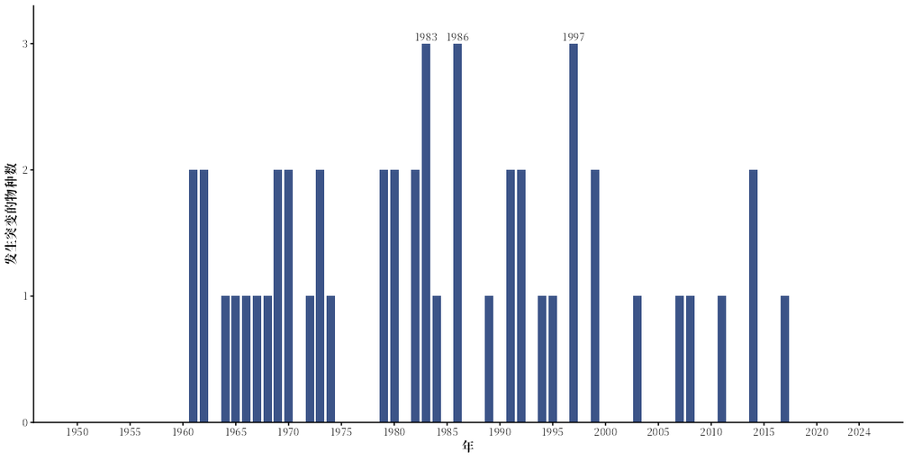

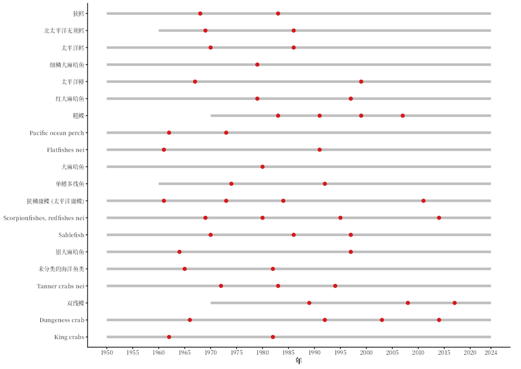

🔎 *怎么看这张图*：每个主要物种的突变点按第4步的方法找出；柱状图统计每一年有多少个物种的平均渔获量在该年发生了变化。许多物种在同一年一起变化，说明存在共同的原因：海洋环境（生态系统转变，regime shift）、管理措施的改变，或上报方式的改变。

*67区的结果*：同时出现突变点最多的年份是1983年（3个物种）、1986年（3个物种）、1997年（3个物种）。北太平洋在1977年和1989年发生过著名的气候生态系统转变（Hare和Mantua，2000），但渔获量的突变点却集中在1980年代，即渔获从外国船队转到美国船队的那些年。在渔获数据中，船队和管理留下的痕迹往往比海洋更明显；单凭突变点无法判断是哪一种原因。

### 7.5 全部FAO渔区的比较：`area_overview()`

```r
overview <- area_overview()
```

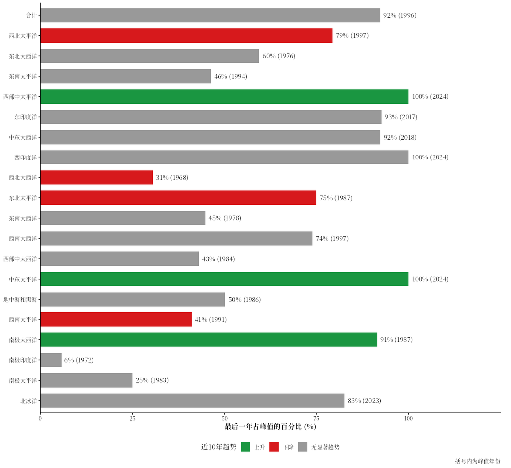

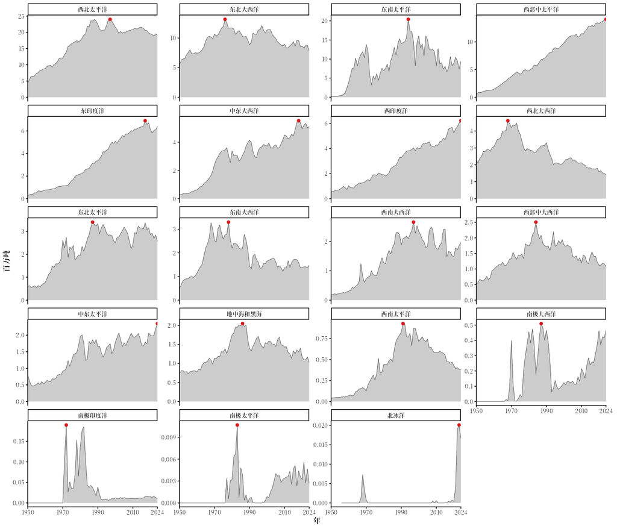